# Titanic Data Analysis with R

Lahee Kim

2022-08-08

## Goal

missing value를 제외한 분석 결과와 missing value를 채워서 분석한 결과에 차이가 있는지 확인해서 유실된 데이터의 값을 찾아내는 것 또는 그것을 추정하는 것이 의미있는지 알아보려고 합니다.

## Prepare

타이타닉의 <train> dataset은 891행 12열로 승객ID, 생존여부, 승선등급, 이름, 성별, 나이, 가족여부, 티켓종류, 요금, cabin, 승선지 데이터가 들어있습니다.

```r
titanic <- read.csv('./data/titanic/train.csv', header = T, stringsAsFactors = T)
str(titanic)
```

```
## 'data.frame':    891 obs. of  12 variables:
##  $ PassengerId: int  1 2 3 4 5 6 7 8 9 10 ...
##  $ Survived   : int  0 1 1 1 0 0 0 0 1 1 ...
##  $ Pclass     : int  3 1 3 1 3 3 1 3 3 2 ...
##  $ Name       : Factor w/ 891 levels "Abbing, Mr. Anthony",..: 109 191 358 277 16 559 520 629 417 581 ...
##  $ Sex        : Factor w/ 2 levels "female","male": 2 1 1 1 2 2 2 2 1 1 ...
##  $ Age        : num  22 38 26 35 35 NA 54 2 27 14 ...
##  $ SibSp      : int  1 1 0 1 0 0 0 3 0 1 ...
##  $ Parch      : int  0 0 0 0 0 0 0 1 2 0 ...
##  $ Ticket     : Factor w/ 681 levels "110152","110413",..: 524 597 670 50 473 276 86 396 345 133 ...
##  $ Fare       : num  7.25 71.28 7.92 53.1 8.05 ...
##  $ Cabin      : Factor w/ 148 levels "","A10","A14",..: 1 83 1 57 1 1 131 1 1 1 ...
##  $ Embarked   : Factor w/ 4 levels "","C","Q","S": 4 2 4 4 4 3 4 4 4 2 ...
```

```r
summary(titanic)
```

```
##   PassengerId       Survived          Pclass
##  Min.   :  1.0   Min.   :0.0000   Min.   :1.000
##  1st Qu.:223.5   1st Qu.:0.0000   1st Qu.:2.000
##  Median :446.0   Median :0.0000   Median :3.000
##  Mean   :446.0   Mean   :0.3838   Mean   :2.309
##  3rd Qu.:668.5   3rd Qu.:1.0000   3rd Qu.:3.000
##  Max.   :891.0   Max.   :1.0000   Max.   :3.000
##
##                                     Name         Sex           Age
##  Abbing, Mr. Anthony                  :  1   female:314   Min.   : 0.42
##  Abbott, Mr. Rossmore Edward          :  1   male  :577   1st Qu.:20.12
##  Abbott, Mrs. Stanton (Rosa Hunt)     :  1                Median :28.00
##  Abelson, Mr. Samuel                  :  1                Mean   :29.70
##  Abelson, Mrs. Samuel (Hannah Wizosky):  1                3rd Qu.:38.00
##  Adahl, Mr. Mauritz Nils Martin       :  1                Max.   :80.00
##  (Other)                              :885                NA's   :177
##      SibSp           Parch             Ticket         Fare
##  Min.   :0.000   Min.   :0.0000   1601    :  7   Min.   :  0.00
##  1st Qu.:0.000   1st Qu.:0.0000   347082  :  7   1st Qu.:  7.91
##  Median :0.000   Median :0.0000   CA. 2343:  7   Median : 14.45
##  Mean   :0.523   Mean   :0.3816   3101295 :  6   Mean   : 32.20
##  3rd Qu.:1.000   3rd Qu.:0.0000   347088  :  6   3rd Qu.: 31.00
##  Max.   :8.000   Max.   :6.0000   CA 2144 :  6   Max.   :512.33
##                                   (Other) :852
##          Cabin     Embarked
##             :687    :  2
##  B96 B98    :  4   C:168
##  C23 C25 C27:  4   Q: 77
##  G6         :  4   S:644
##  C22 C26    :  3
##  D          :  3
##  (Other)    :186
```

NA가 아닌 “” 같은 빈 문자열이 있는 경우에는 describe 함수에서 부족한 행의 라인수로 결측치가 있음을 확인할 수 없습니다.

```r
psych::describe(titanic)
```

```
##             vars   n   mean     sd median trimmed    mad  min    max  range
## PassengerId    1 891 446.00 257.35 446.00  446.00 330.62 1.00 891.00 890.00
## Survived       2 891   0.38   0.49   0.00    0.35   0.00 0.00   1.00   1.00
## Pclass         3 891   2.31   0.84   3.00    2.39   0.00 1.00   3.00   2.00
## Name*          4 891 446.00 257.35 446.00  446.00 330.62 1.00 891.00 890.00
## Sex*           5 891   1.65   0.48   2.00    1.68   0.00 1.00   2.00   1.00
## Age            6 714  29.70  14.53  28.00   29.27  13.34 0.42  80.00  79.58
## SibSp          7 891   0.52   1.10   0.00    0.27   0.00 0.00   8.00   8.00
## Parch          8 891   0.38   0.81   0.00    0.18   0.00 0.00   6.00   6.00
## Ticket*        9 891 339.52 200.83 338.00  339.65 268.35 1.00 681.00 680.00
## Fare          10 891  32.20  49.69  14.45   21.38  10.24 0.00 512.33 512.33
## Cabin*        11 891  18.63  38.14   1.00    8.29   0.00 1.00 148.00 147.00
## Embarked*     12 891   3.53   0.80   4.00    3.66   0.00 1.00   4.00   3.00
##              skew kurtosis   se
## PassengerId  0.00    -1.20 8.62
## Survived     0.48    -1.77 0.02
## Pclass      -0.63    -1.28 0.03
## Name*        0.00    -1.20 8.62
## Sex*        -0.62    -1.62 0.02
## Age          0.39     0.16 0.54
## SibSp        3.68    17.73 0.04
## Parch        2.74     9.69 0.03
## Ticket*      0.00    -1.28 6.73
## Fare         4.77    33.12 1.66
## Cabin*       2.09     3.07 1.28
## Embarked*   -1.27    -0.16 0.03
```

**결측치 분포 그래프**

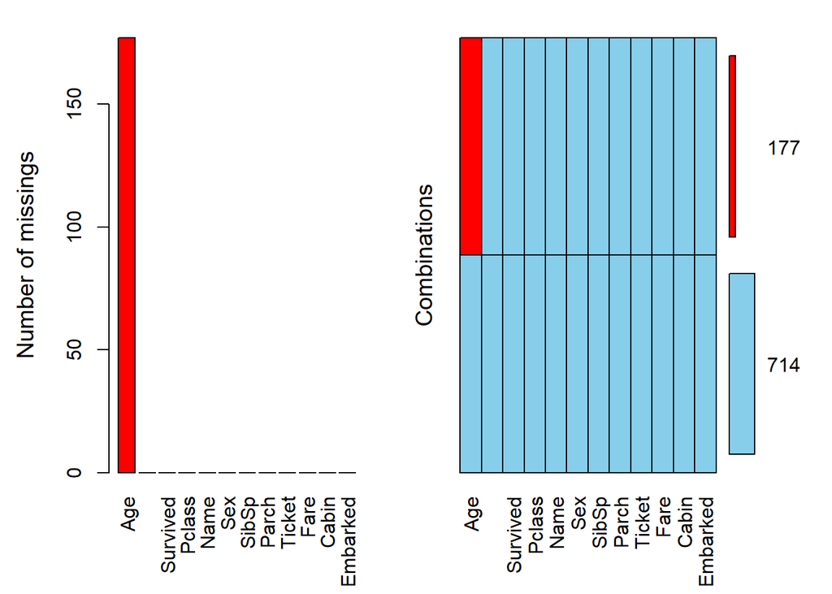

```
##
##  Variables sorted by number of missings:
##     Variable Count
##          Age   177
##  PassengerId     0
##     Survived     0
##       Pclass     0
##         Name     0
##          Sex     0
##        SibSp     0
##        Parch     0
##       Ticket     0
##         Fare     0
##        Cabin     0
##     Embarked     0
```

```r
VIM::aggr(titanic, numbers = T, prop = F, sortVars = T)
```

Cabin, Embarked 데이터의 빈 문자열 “” 을 NA로 바꿉니다.

```r
titanic$Cabin[titanic$Cabin == ""] <- NA
titanic$Embarked[titanic$Embarked == ""] <- NA
sum(is.na(titanic$Cabin))
```

```
## [1] 687
```

```r
sum(is.na(titanic$Embarked))
```

```
## [1] 2
```

## Start

```r
# 결측 데이터 제외 후 factor value를 numeric으로 변환
titanic2 <- na.omit(titanic)
class(titanic$Age)
```

```
## [1] "numeric"
```

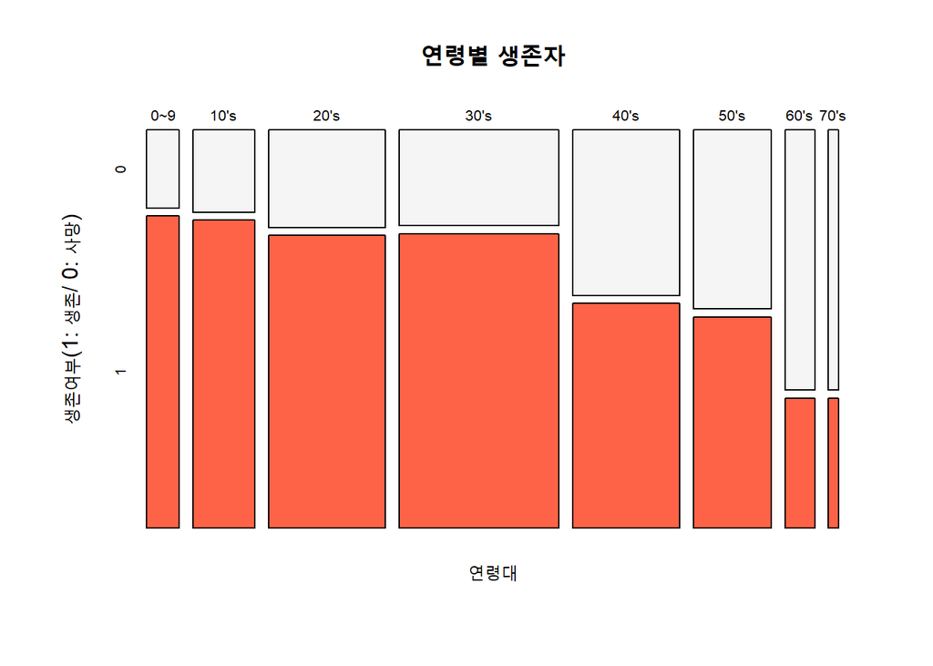

```r
# 연령대 생성
titanic2 <- transform(titanic2,
                      Ages = cut(titanic2$Age,
                                 breaks = c(0.42, 10.00, 20.00, 30.00, 40.00, 50.00, 60.00, 70.00, 80.00),
                                 include.lowest = TRUE,
                                 right = FALSE,
                                 labels = c("0~9", "10's", "20's", "30's", "40's", "50's", "60's", "70's")))

# 연령대별 생존자수
mosaicplot(Ages ~ Survived, data = titanic2,
           color = c("whitesmoke", "tomato"),
           main = "연령별 생존자",
           xlab = "연령대",
           ylab = "생존여부(1: 생존/ 0: 사망)")
```

### 2. 잃어버린 값을 추측해보기

nanny와 함께 탑승한 일부 어린이들은 parch 데이터에 0으로 기록 되었다고 나옵니다.

나이가 비어있는 사람 중에 SibSp와 parch 기록이 0이라면 어린 나이로 추정해볼 수 있습니다. 그런데 Chibnall, Mrs. (Edith Martha Bowerman)나 Lurette, Miss. Elise처럼 가족이 없는데 1등급이고 지불요금이 상당한데다 Cabin이었던 사람들 중 나이 기록이 비어있는 경우가 있습니다.

따라서 나이를 추정해볼 수 있는 관련 요인으로 Cabin, SibSp, parch, 요금, 성별, 승선등급 총 6가지 정도의 기록과 비교해서 동일 그룹을 찾아 해당 그룹의 평균값으로 잃어버린 데이터를 채워서 전체 승객의 연령별 생존 비율을 제대로 구해보면 좋을 것 같습니다.

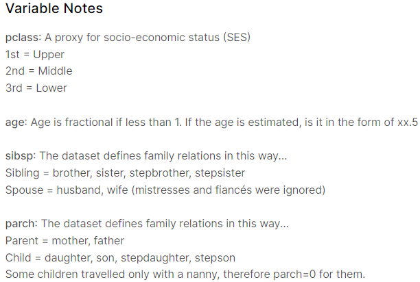

Variable-Notes

남자 선원과 여자 선원의 평균 나이 38세, 33세

```r
maleCabin <- titanic[(titanic$Cabin != "") & (titanic$Sex == 'male'), ]
maleAvg <- mean(maleCabin$Age, na.rm=T)
maleAvg
```

```
## [1] 38.45179
```

```r
femaleCabin <- titanic[(titanic$Cabin != "") & (titanic$Sex == 'female'), ]
femaleAvg <- mean(femaleCabin$Age, na.rm=T)
femaleAvg
```

```
## [1] 33.06111
```

```r
table(titanic[!titanic$Age == "NA", "Embarked"])
```

```
##
##       C   Q   S
##   0 130  28 554
```

[figure not shown]

```r
barplot(table(titanic[!titanic$Age == "NA", "Embarked"]),
        main = "나이 기록 유실이 많았던 승선지",
        xlab = "Embarked")
```

승선 등급에서는 3 > 1 > 2등급 순으로 나이 기록이 없었습니다.

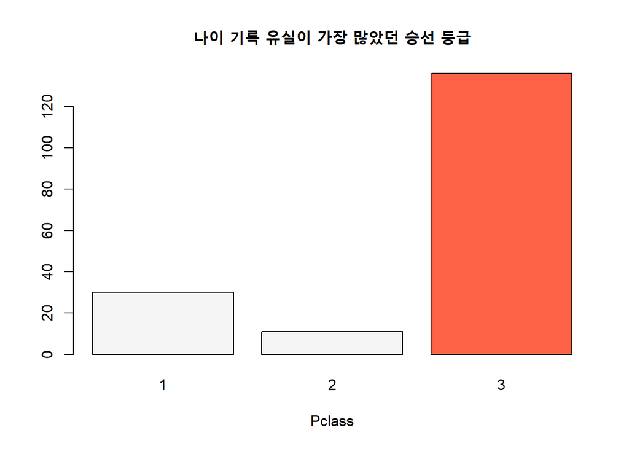

```r
ageMissing <- titanic[!complete.cases(titanic$Age), ]
barplot(table(ageMissing$Pclass),
        main = "나이 기록 유실이 가장 많았던 승선 등급",
        xlab = "Pclass",
        col = c("whitesmoke", "whitesmoke", "tomato"))
```

동승자가 없는데 승선 요금이 비싸고 1등급일 경우 연령대가 높을 수 있다고 생각해 볼 수 있습니다.

```r
max_fare <- max(ageMissing$Fare)
which(ageMissing$Fare == max_fare)
```

```
## [1] 115
```

```r
ageMissing[115, ]
```

```
##     PassengerId Survived Pclass                Name  Sex Age SibSp Parch
## 558         558        0      1 Robbins, Mr. Victor male  NA     0     0
##       Ticket    Fare Cabin Embarked
## 558 PC 17757 227.525  <NA>        C
```